# 灾害事件中的情绪与行为 · Current 结果

## 灾害事件中的情绪与行为

Pipeline: 情绪识别 → 行为抽取 → 时空动态贝叶斯网络  
Stage 1 · Stage 2 · Stage 3

Date: 2026-10-21

95%可信区间(CrI) · ➕[区间不含0，显著] · ⭕[区间含0，不显著]

## 流程总览: 三个阶段回答三个问题

研究设计

**01 · Stage 1**

每条微博 → 六类情绪概率 → 负面情绪分数 E

·

**02 · Stage 2**

每条微博 → 社会失序行为信号分数 B + 证据 span 抽取

·

**03 · Stage 3**

E、B 汇入”事件 × 时间 × 距离”网格, 用 DBN 建模估计共变与滞后

三个阶段把约100万条灾害微博,压缩成”哪个时段、离灾点多远、负面情绪与行为信号如何共同变化”的时空规律。

Notation: **E** = P(angry)+P(fear)+P(sad), 负面情绪模型分数; **B** = `behavior_prob`, 社会失序行为信号分数。θ₁ = 情绪与行为的**同期共变**, θ₂ = 情绪对行为的**滞后**关联。

## Stage 1 · 情绪模型

STAGE 01 / 03

微博文本 → 六类情绪概率 → 负面情绪分数 E

模型设置(语料与训练) → 评估结果(整体准确、负面小类偏弱)

## Stage 1 模型设置: 语料、模型与输出

Stage 1 · 模型设置

| 项目 | 设置 |
| --- | --- |
| 语料 | SMP2020-EWECT(微博情绪分类公开语料) |
| 训练集 / 官方评估集 | 27,810 条 / 2,000 条 |
| 模型 | Chinese RoBERTa-wwm-ext, 六分类: angry、happy、neutral、surprise、sad、fear |
| 训练参数 | 最大长度 64 · batch 16 · epoch 3 · 学习率 `2e-5` · 种子 42 |
| Stage 3 情绪输入 | E = P(angry)+P(fear)+P(sad) |

训练集类别分布: angry 8,345 · neutral 5,745 · happy 5,378 · sad 5,020 · surprise 2,082 · fear 1,240。

Stage 1的作用是给四类灾害提供**尺度可比的负面情绪分数**: 后面所有关于情绪的分析, 都使用每条微博打出的三个负面情绪概率之和。

## Stage 1 结果: 整体准确, 负面小类偏弱

Stage 1 · 结果

总体 Accuracy `0.7720`, macro-F1 `0.7371`(官方评估集 N = 2,000)。

| 类别 | Precision | Recall | F1 | 样本数 |
| --- | --- | --- | --- | --- |
| neutral | 0.8951 | 0.8333 | **0.8631** | 420 |
| angry | 0.8166 | 0.8208 | **0.8187** | 586 |
| happy | 0.7717 | 0.7954 | **0.7834** | 391 |
| sad | 0.6531 | 0.6965 | **0.6741** | 346 |
| fear | 0.5702 | 0.7931 | **0.6635** | 87 |
| surprise | 0.7244 | 0.5412 | **0.6195** | 170 |

模型约四分之三的判断正确, neutral、angry、happy识别最稳; 但 fear 的精确率只有 0.57。

## Stage 2 · 行为抽取

STAGE 02 / 03

微博文本 → 社会失序行为信号分数 B + 可定位证据 span

模型设置(标注与训练) → 结果 1(交叉验证) → 结果 2(百万微博输出规模)

## Stage 2 模型设置: 只读文本的信号抽取器

Stage 2 · 模型设置

| 项目 | 设置 |
| --- | --- |
| 标注数据 | 1,000 条微博(347 阳性 / 653 阴性), 528 个证据 span |
| 数据来源 | 非合成 800 条 + 合成 200 条; 台风 444、泥石流 195、地震 184、滑坡 96 等 |
| 验证设计 | 611 个防泄漏分组; 5 折分组交叉验证 × 3 个种子 = 15 次评估 |
| 模型结构 | Chinese RoBERTa-wwm-ext + presence 分类头 + O/B/I 线性链 CRF |
| 损失函数 | CRF NLL + 0.25×tag CE + 0.5×presence CE |
| 模型输入 | 仅文本; 不读情绪、灾害强度、人口、GDP 等任何协变量 |

这一阶段的任务是**找有害行为信号(prob), 无法认定真实行为的发生(0/1)**: 模型判断微博里是否出现与有害行为相关的表述, 并输出连续分数B作为Stage 3的行为输入。

## Stage 2 结果 1: 帖子级判断强, span 边界定位难

Stage 2 · 结果 1/5 交叉验证

| 评估层面 | 指标 | 均值 ± 标准差 |
| --- | --- | --- |
| 帖子级判别 | Accuracy | 0.9420 ± 0.0219 |
| 帖子级判别 | F1 | 0.9125 ± 0.0332 |
| 连续 presence 分数 | PR-AUC | 0.9669 ± 0.0089 |
| span 严格边界 | F1 | 0.4862 ± 0.0312 |
| span 字符重叠 | F1 | 0.6546 ± 0.0545 |
| checkpoint 选择 | selection span F1 | 0.5704 ± 0.0381 |

“这条微博有没有有害行为信号”的判断接近 0.94, 但把证据片段的**起止边界画准**很难(严格 F1 约 0.49)。模型知道信号在哪里, 却画不准边界——所以 Stage 3 用连续分数 `behavior_prob`, 不用二值标签或 span 计数。

帖子级 Precision 0.9585、Recall 0.8714。部署模型: seed 42、6 epochs (15 次交叉验证最佳 epoch 的中位数)。

## Stage 2 结果 2: 百万微博的行为信号密度

Stage 2 · 结果 2/5 全量输出

| 灾种 | 输出帖子数 | presence 阳性率(≥0.5) | span 阳性率 | 抽取 span 总数 |
| --- | --- | --- | --- | --- |
| 地震 | 30,280 | 6.94% | 1.96% | 762 |
| 滑坡 | 21,900 | 6.62% | 1.82% | 461 |
| 泥石流 | 25,937 | 6.35% | 1.50% | 483 |
| 台风 | 929,094 | 6.31% | 1.69% | 19,196 |
| **合计** | **1,007,211** | **6.34%** | **1.70%** | **20,902** |

全量100.7万条微博中约**6.3%**带较高行为信号、**1.7%**能抽出span。这些比例指**社会失序行为在社交媒体上的密度**; 台风贡献了九成以上数据。

presence(连续分数)与span(证据片段)是两个独立输出, 阳性率不要求相等; Stage 3使用全部帖子的连续分数, 没有设阈值。

## Stage 2 结果 3: 行为词频——出行中断与日常失序为主体, 违法类是低频尾部

Stage 2 · 结果 3/5 行为 span 词频统计

| 灾种 | 唯一帖数 | 高频行为词 Top 6(去重词频) |
| --- | --- | --- |
| 地震 | 1,027 | 犯罪(11) · 诈骗(10) · 停车(9) · 逃离(9) · 造谣(9) · 疯狂(9) |
| 滑坡 | 728 | 停运(12) · 非法(12) · 采矿(11) · 救援(11) · 爬山(10) · 出门(7) |
| 泥石流 | 733 | 交通管制(30) · 逃离(19) · 诈骗(11) · 临时(10) · 封路(8) · 排队(8) |
| 台风 | 12,274 | 逃离(251) · 停运(202) · 取消(140) · 出门(136) · 停课(125) · 回家(106) |

四灾种高频行为词**同构**: 主体是**“出行与活动中断”**(停运/取消/停课/封路/闭园/交通管制)加**“日常轻微失序”**(逃离/回家/排队), **“违法违纪类”**(诈骗/造谣/犯罪/非法采矿)只出现在低频尾部。

## Stage 2 结果 4: LDA 无灾种特异行为主题——主题占比均匀

Stage 2 · 结果 4/5 LDA 主题模型

| 灾种 | K=5 主题占比范围 | 主题词示例(节选) |
| --- | --- | --- |
| 地震 | 19.0–20.8% | 逃离/回家 · 逃税/加班 · 造谣/羁押 · 禁止吸烟 · 犯罪/诈骗 |
| 滑坡 | 19.5–20.5% | 非法采矿/救援 · 回家/换乘 · 封路/排队 · 爬楼/逃离 · 停运/占用 |
| 泥石流 | 19.1–21.1% | 逃离/闭园 · 吸氧/房租 · 排队/诉讼 · 诈骗/封路 · 交通管制/摆摊 |
| 台风 | 18.9–20.8% | 回家/赶地铁 · 免费停车/摆摊 · 停课/闭园 · 停运/退票/改签 · 逃离/收费 |

每个灾种K=5的主题占比全部挤在**19–21%的均匀带**内, 且主题词都是日常事务(出行中断、消费纠纷、管理管制、违法个案), **没有可命名的灾种特异行为主题**——行为信号的类别构成跨灾种同质, 差异主要在体量。

## Stage 2 结果 5: 远环情绪回弹是城镇日常帖的构成效应

Stage 2 · 结果 5/5 帖子级构成分解(地震)

| 距离带 | 帖数 | 提灾率(震后 0–12 h) | E(不提灾帖) | 怒(不提灾帖) | 惧(不提灾帖) |
| --- | --- | --- | --- | --- | --- |
| 近环 0–15 km | 9,319 | 32.6% | 0.301 | 0.115 | 0.027 |
| 中环 20–35 km | 8,463 | 6.6% | 0.280 | 0.107 | 0.020 |
| 远环 40–50 km | 4,139 | 1.4% | 0.295 | 0.117 | 0.020 |

地震提及率随距离减少(震后 0–12 h: 32.6% → 6.6% → 1.4%), 远环的情绪抬升完全由**日常帖**贡献; 不提灾害的帖子中, 远环E仍高于中环(ΔE = +0.015, p = 0.016), 且**全部由”angry”驱动**(Δangry = +0.010, p = 0.009; fear无差, p = 0.50)——远环回弹是由于城镇日常帖基线怒气高于乡野的地理构成, 不是灾害情绪外溢。

旁证: 远环富集词为城市生活词(3–16 倍); 上海青浦事件**中环也是城区**就**没有回弹**( ≈ 0); 事件级回弹与远环人口/GDP 零相关(r ≤ 0.08)。该结果仅在地震成立——滑坡/泥石流无此特征, 台风远环由sad/fear构成。

## Stage 3 · 时空 DBN

STAGE 03 / 03

E、B 序列 → 共变 θ₁、滞后 θ₂ 与时间、距离曲线

设置 1(时空网格) → 设置 2(方程与参数) → 结果 1–7(核心参数 / 灾害特征 / 人口 GDP / 时间峰值 / 空间轮廓 / 拟合误差 / 敏感性)

## Stage 3 设置 1: 时空网格与观测稀疏性

Stage 3 · 模型设置 1/2

时间窗: 相对灾害时刻**`[-72, +168)`**小时、每`12小时`一窗、共`20`窗; 地震、滑坡、泥石流用`5km × 10环`,台风用`10km × 20环`。

| 灾种 | 事件结构 | 完整网格 | 有观测比例 | 每格帖子中位数 | 进入似然帖子 |
| --- | --- | --- | --- | --- | --- |
| 地震 | 37 个事件 | 7,400 | 46.4% | 3 | 23,564 |
| 滑坡 | 30 个事件 | 6,000 | 25.2% | 2 | 11,772 |
| 泥石流 | 36 个事件 | 7,200 | 23.5% | 2 | 13,257 |
| 台风 | 14 个台风 / 53 个路径点 | 21,200 | 61.7% | 6 | 358,576 |
| **合计** | — | **41,800** | **47.2%** | — | **407,169** |

微博帖子聚合至”事件 × 时间窗 × 距离环”的栅格, 但只有约**47%**的栅格有帖子, 滑坡和泥石流每个栅格往往只有2条, 结论依赖模型平滑。

## Stage 3 设置 2: DBN 核心方程与参数含义

Stage 3 · 模型设置 2/2

$$e_{jkt}=\text{base}_{e,jkt}+\beta_e\,e_{jk,t-1}+\varepsilon^E_{jkt} ， b_{jkt}=\text{base}_{b,jkt}+\beta_b\,b_{jk,t-1}+\theta_1\,e_{jkt}+\theta_2\,e_{jk,t-1}+\varepsilon^B_{jkt}$$

参数

模型含义

事件中的实际含义

θ₁

同期 E→B 耦合

同一个时间窗里, 情绪更高时行为信号是否一起升高(**共变**)

θ₂

前一窗 E→当期 B

前一时间窗的情绪是否预示随后的行为信号(**滞后**)

βₑ / β_b

E / B 一阶自回归

情绪或行为是否延续自身上一窗的状态(惯性)

基线

时间样条 + 距离样条 + 事件随机截距 + 灾害特征

控制事件节奏、距离衰减和灾种强度后的参照水平

θ₁ 回答”情绪与行为是否**同期共变**”, θ₂ 回答”前一窗的情绪能否**预示下一窗**的行为信号”(滞后)。两者是控制基线后的条件关联。

情绪观测在logit尺度用正态分布, 行为观测用Beta分布。台风另含”台风—路径点”嵌套随机截距, 地震含灾后跳跃项。

## Stage 3 结果 1: θ₁ 四灾皆显著, θ₂ 仅地震与台风显著

Stage 3 · 结果 1/7 核心参数

| 灾种 | θ₁ 同期共变 E→B | θ₂ 滞后 E→B | βₑ 情绪惯性 | β_b 行为惯性 |
| --- | --- | --- | --- | --- |
| 地震 | ➕ 0.0893 [0.0701, 0.1098] | ➕ 0.0233 [0.0004, 0.0494] | ⭕ 0.0038 [−0.0054, 0.0134] | ➕ 0.0280 [0.0155, 0.0399] |
| 滑坡 | ➕ 0.0369 [0.0198, 0.0541] | ⭕ 0.0120 [−0.0099, 0.0332] | ➕ 0.0187 [0.0062, 0.0312] | ⭕ 0.0131 [−0.0013, 0.0283] |
| 泥石流 | ➕ 0.0336 [0.0186, 0.0489] | ⭕ −0.0001 [−0.0140, 0.0126] | ⭕ −0.0033 [−0.0143, 0.0075] | ⭕ 0.0069 [−0.0036, 0.0181] |
| 台风 | ➕ 0.1462 [0.1339, 0.1584] | ➕ 0.0549 [0.0409, 0.0685] | ➕ 0.0317 [0.0283, 0.0350] | ➕ 0.0320 [0.0242, 0.0391] |

**四类灾害中 θ₁ 全部为正**——灾害期间, 同一时空格里负面情绪越高, 社会失序行为信号也越高, 即情绪与行为信号**同期共变**; 而**滞后效应** **θ₂** 只在地震(下界贴近0)和台风成立, 滑坡、泥石流不支持。

## Stage 3 结果 2: 灾害强度与情绪相关，与行为信号基本无关

Stage 3 · 结果 2/7 灾害特征

连续特征已在灾种内标准化: 系数 = 特征每增加1个标准差, 潜在logit状态的变化。

| 灾种 | 灾害特征 | 对 E 的系数 | 对 B 的系数 |
| --- | --- | --- | --- |
| 地震 | 震级 | ➕ 0.0379 [0.0246, 0.0508] | ⭕ −0.0153 [−0.0378, 0.0083] |
| 地震 | 深度 | ➕ −0.0411 [−0.0532, −0.0291] | ⭕ −0.0162 [−0.0406, 0.0064] |
| 地震 | 灾后阶跃(0h) | ➕ 0.3838 [0.3702, 0.3971] | ➕ −0.2646 [−0.2862, −0.2419] |
| 滑坡 | 72 h 最大降雨量 | ⭕ 0.0058 [−0.0115, 0.0234] | ⭕ −0.0025 [−0.0300, 0.0236] |
| 泥石流 | 1 h 最大降雨强度 | ➕ 0.0673 [0.0508, 0.0841] | ➕ 0.0567 [0.0333, 0.0796] |
| 台风 | 台风等级 | ➕ 0.0946 [0.0909, 0.0984] | ⭕ −0.0102 [−0.0251, 0.0032] |

## Stage 3 结果 3: 人口密度与行为基线相关, 经济密度调节共变强度

Stage 3 · 结果 3/7 人口密度与经济密度

在原结构上联合加入`人口密度`(2020年1km网格的人口数) 与`经济密度`(2020年1km网格的GDP(万元)) (每环栅格均值、log1p、灾种内标准化)。POP–GDP: r 0.71–0.81, VIF 2–3, 无严重共线。

| 灾种 | 变量 | 对 E 主效应 | 对 B 条件主效应 | 对 θ₁ 调节 | 对 θ₂ 调节 |
| --- | --- | --- | --- | --- | --- |
| 地震 | POP | 0.140 ➕ | 0.036 ➕ | −0.030 ➕ | 0.013 ⭕ |
| 地震 | GDP | −0.044 ➕ | 0.006 ⭕ | 0.023 ➕ | −0.020 ⭕ |
| 滑坡 | POP | 0.309 ➕ | 0.147 ➕ | 0.012 ⭕ | −0.001 ⭕ |
| 滑坡 | GDP | −0.065 ➕ | 0.006 ⭕ | 0.022 ➕ | 0.025 ➕ |
| 泥石流 | POP | 0.106 ➕ | 0.070 ➕ | 0.013 ⭕ | 0.014 ⭕ |
| 泥石流 | GDP | 0.067 ➕ | 0.077 ➕ | 0.024 ➕ | 0.011 ⭕ |
| 台风 | POP | 0.041 ➕ | 0.111 ➕ | 0.013 ⭕ | 0.012 ➕ |
| 台风 | GDP | 0.065 ➕ | 0.014 ➕ | 0.007 ⭕ | −0.018 ➕ |

**人越密, 情绪与行为信号基线都越高**(四灾一致); GDP不普遍与行为基线有关, 却在地震、滑坡、泥石流**放大 θ₁**——经济更发达的地方, 情绪与行为的同期共变更强。控制人口/GDP后, 四灾条件 θ₁ 仍全部为正。

## Stage 3 结果 4a: 情绪峰值紧贴事件, 行为峰值不明确

Stage 3 · 结果 4/7 时间曲线

| 灾种 | 通道 | 峰值窗口 | 峰值 score [95% CrI] | 峰值抽样占比 |
| --- | --- | --- | --- | --- |
| 地震 | E | +6 h [0,12) | 0.379 [0.370, 0.386] | 100% |
| 滑坡 | E | +18 h [12,24) | 0.324 [0.313, 0.337] | 50.3% |
| 泥石流 | E | +78 h [72,84) | 0.275 [0.265, 0.287] | 63.8% |
| 台风 | E | −6 h [−12,0) | 0.300 [0.298, 0.302] | 100% |
| 地震 | B | −66 h(首窗,边界) | 0.185 [0.179, 0.192] | 47.2% |
| 滑坡 | B | +66 h [60,72) | 0.172 [0.162, 0.183] | 48.2% |
| 泥石流 | B | +162 h(末窗,边界) | 0.164 [0.151, 0.177] | 52.4% |
| 台风 | B | +162 h(末窗,边界) | 0.192 [0.183, 0.201] | 47.8% |

## Stage 3 结果 4b: 晚期回升聚在同一时间窗——灾后第 3–4 天

Stage 3 · 结果 4a 时间曲线局部峰

| 灾种 | E 主峰 | 次级局部峰 | 最高次峰比主峰低 |
| --- | --- | --- | --- |
| 地震 | +6 h = 0.379 | −66 h 0.303 · −18 h 0.335 · +78 h 0.342 · +138 h 0.326 | 10% |
| 滑坡 | +18 h = 0.324 | −42 h 0.324(等高, 真结构) · +78 h 0.301 · +150 h 0.273 | 0% |
| 泥石流 | +78 h 0.275, 主峰本身在晚窗 | −42 h 0.237 · +162 h 0.247(末窗边界) | 11% |
| 台风 | −6 h = 0.300 | −66 h 0.254 · +102 h 0.258 · +162 h 0.262(末窗边界) | 13% |

四灾种的晚期次峰(泥石流为晚主峰)无一例外落在灾后 **+72 至 +102 小时(第3–4天)** 同一窗口——更像跨灾种共享的灾后信息流周期(次生灾害报道、媒体回访、救援转恢复阶段); 机制为推测。

## Stage 3 结果 4c: 时间曲线图 — E 与 B

Stage 3 · 结果 4c 时间曲线 · 上 E / 下 B · 地震 | 滑坡 | 泥石流 | 台风

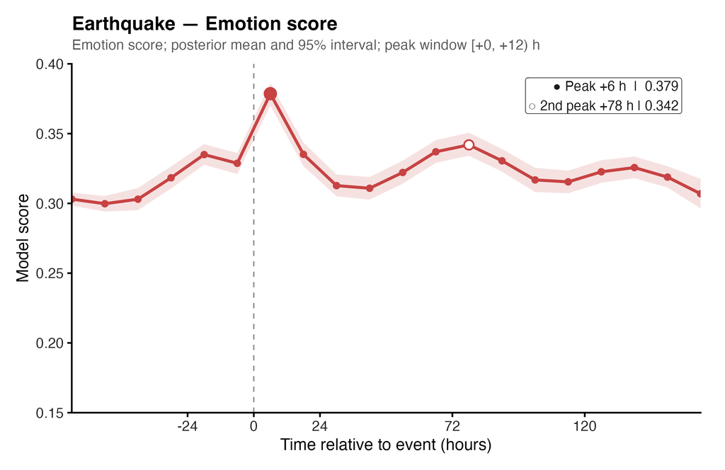

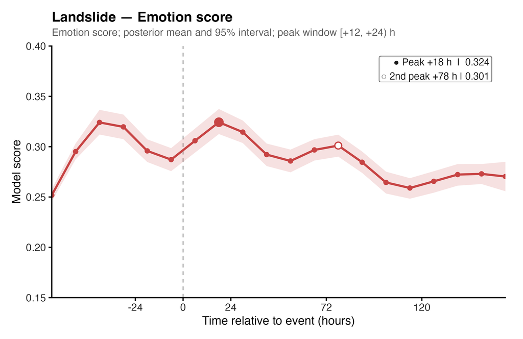

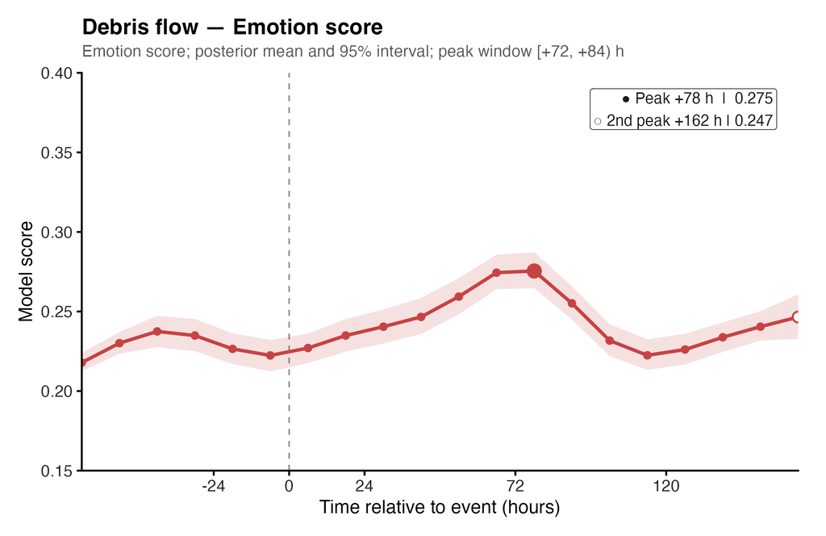

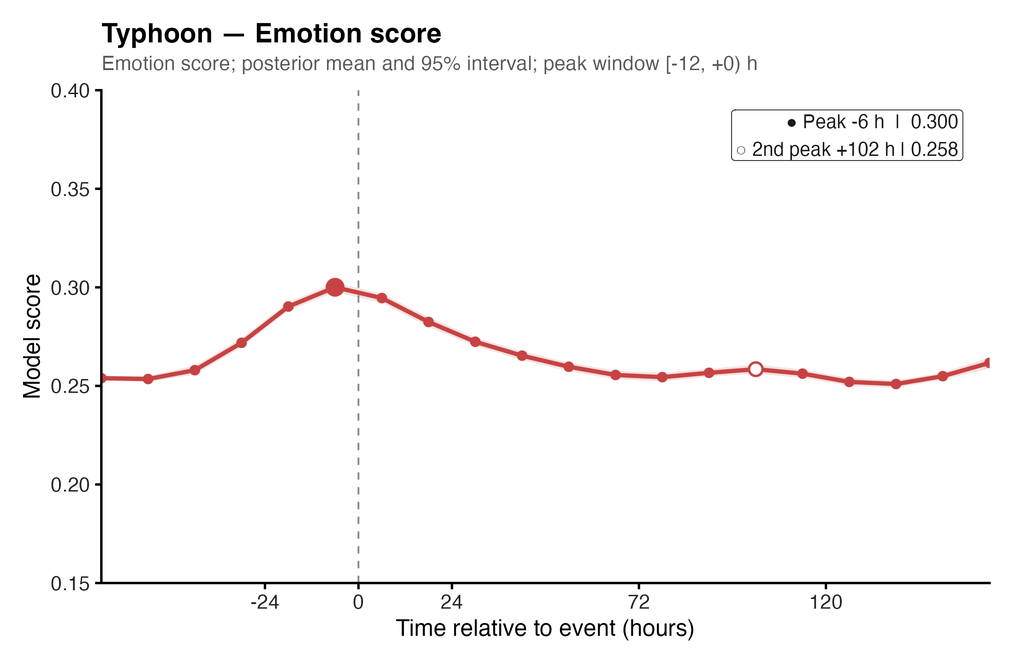

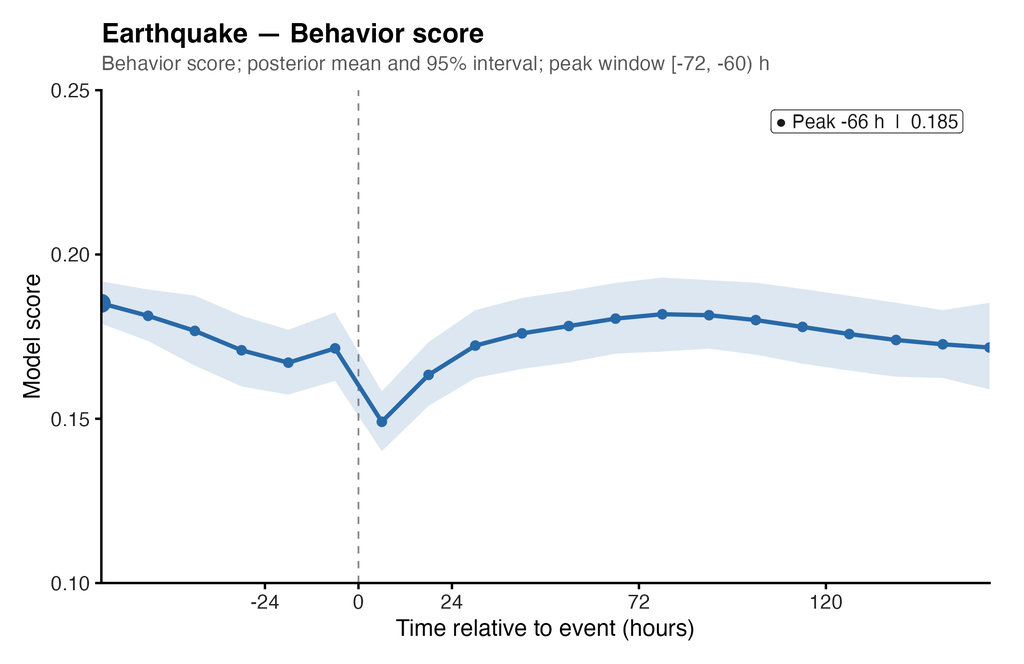

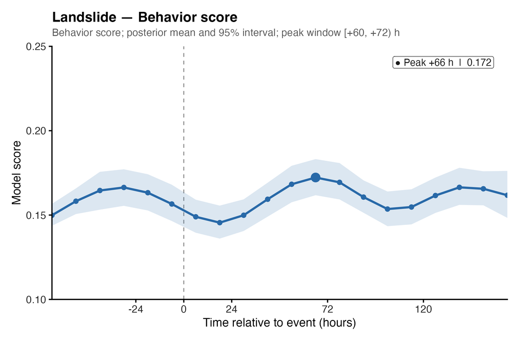

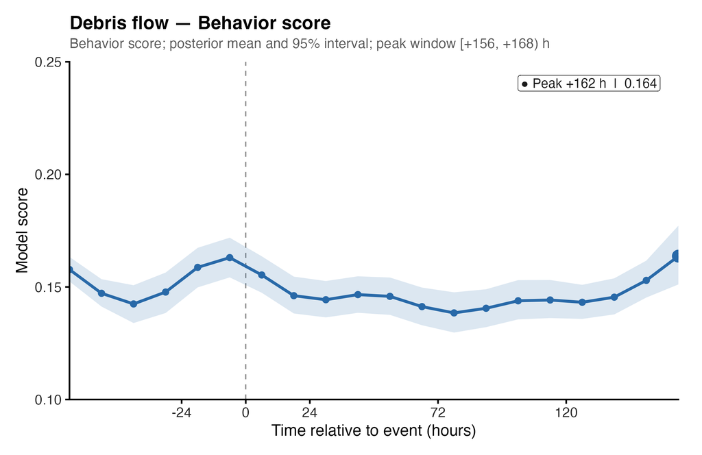

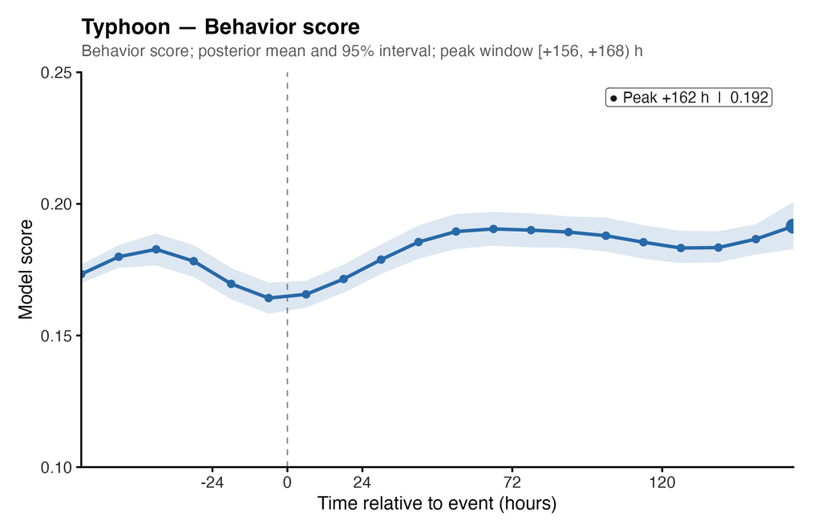

四灾种直接可比。

## Stage 3 结果 5a: 情绪峰值近灾点, 行为峰值在外环

Stage 3 · 结果 5/7 空间曲线

| 灾种 | 通道 | 峰值距离 | 峰值 score [95% CrI] | 峰值抽样占比 |
| --- | --- | --- | --- | --- |
| 地震 | E | 2.5 km | 0.267 [0.265, 0.270] | 100% |
| 滑坡 | E | 2.5 km | 0.289 [0.285, 0.292] | 100% |
| 泥石流 | E | 37.5 km | 0.248 [0.239, 0.258] | 94.0% |
| 台风 | E | 85 km | 0.269 [0.268, 0.271] | 99.3% |
| 地震 | B | 47.5 km(最外环,边界) | 0.210 [0.198, 0.223] | 49.8% |
| 滑坡 | B | 32.5 km | 0.169 [0.159, 0.180] | 90.9% |
| 泥石流 | B | 22.5 km | 0.154 [0.146, 0.162] | 46.9% |
| 台风 | B | 195 km(最外环,边界) | 0.205 [0.198, 0.212] | 91.9% |

## Stage 3 结果 5b: 空间曲线图 — E 与 B

Stage 3 · 结果 5b 空间曲线 · 上 E / 下 B · 地震 | 滑坡 | 泥石流 | 台风

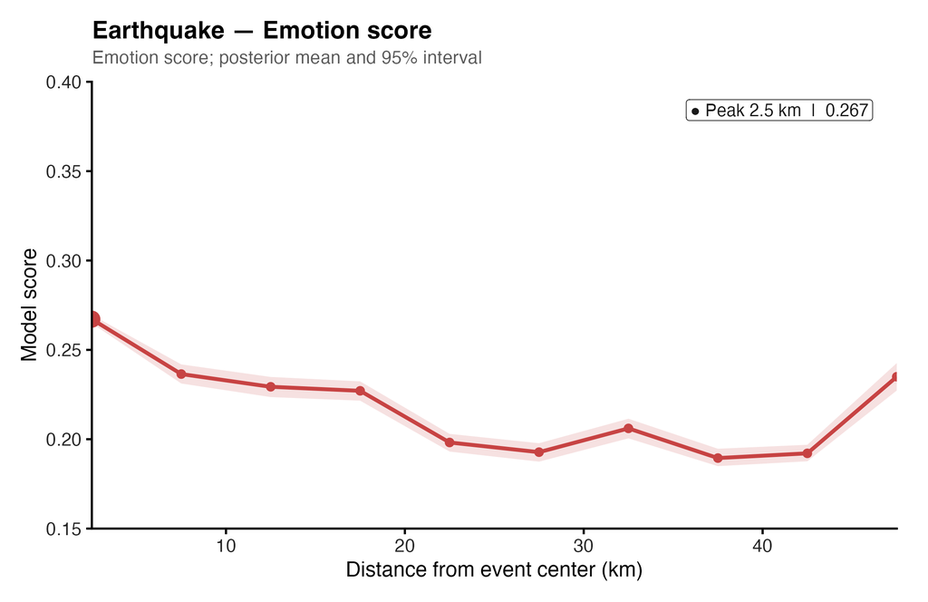

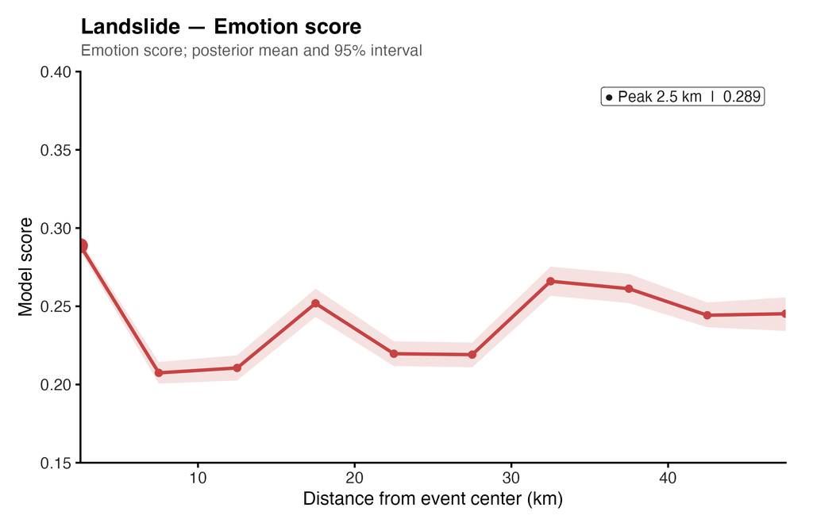

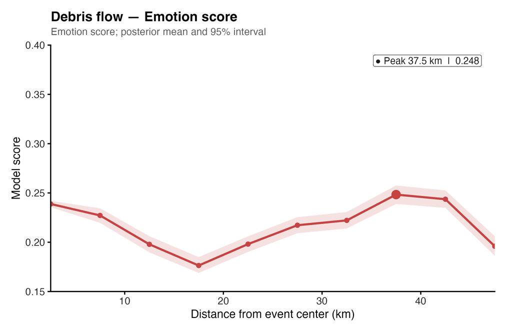

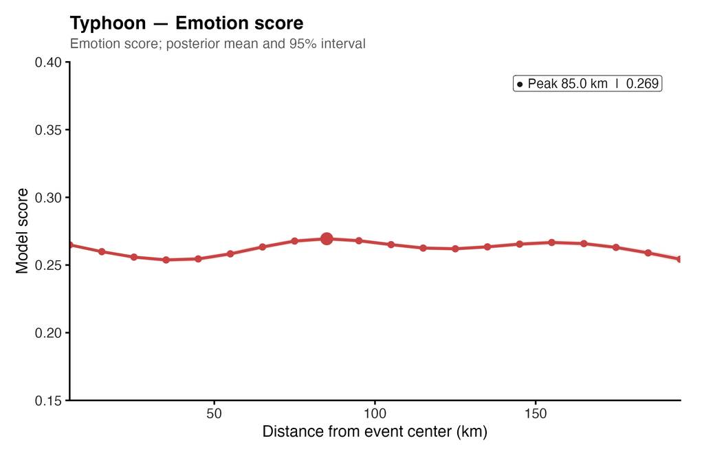

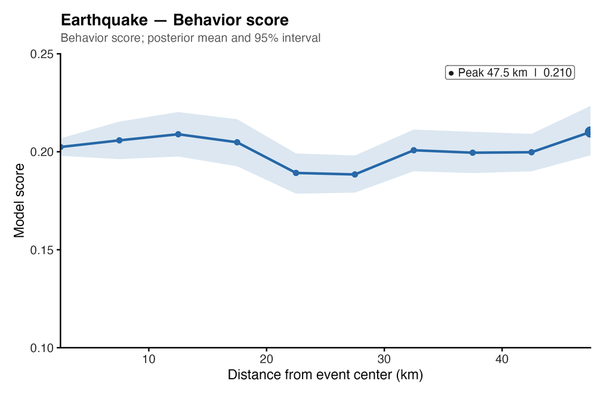

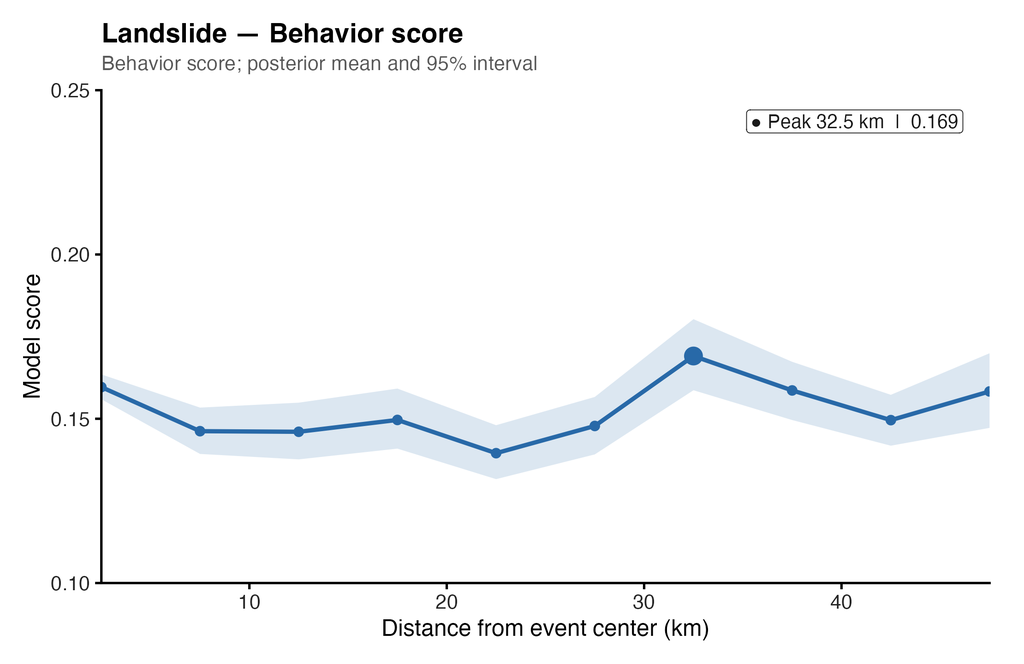

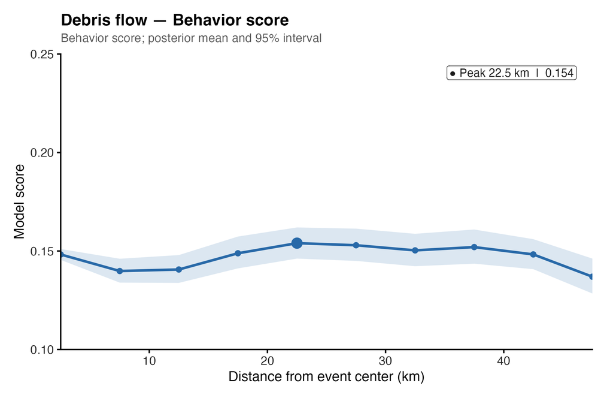

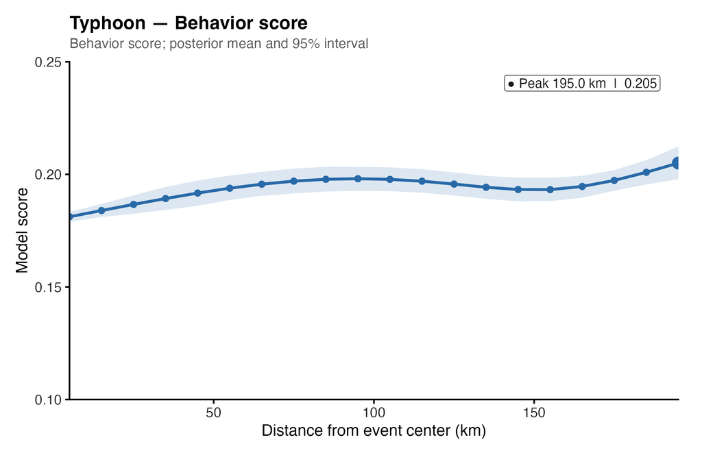

台风为 10 km × 20 环, 其余灾种 5 km × 10 环。

## Stage 3 结果 6: 行为曲线拟合好, 台风情绪区间偏窄

Stage 3 · 结果 6/7 后验预测误差

单元格为 RMSE(95% 覆盖率)。

| 灾种 | E-space | B-space | E-time | B-time |
| --- | --- | --- | --- | --- |
| 地震 | 0.0313 (0.50) | 0.0027 (1.00) | 0.0331 (0.75) | 0.0029 (1.00) |
| 滑坡 | 0.0301 (0.80) | 0.0026 (1.00) | 0.0337 (0.90) | 0.0031 (1.00) |
| 泥石流 | 0.0353 (0.60) | 0.0019 (1.00) | 0.0334 (0.90) | 0.0021 (1.00) |
| 台风 | 0.0237 (0.20) | 0.0020 (1.00) | 0.0226 (0.35) | 0.0018 (1.00) |

行为曲线的后验预测覆盖率全部为1.00, 但**台风情绪曲线覆盖率只有0.20–0.35**——模型对台风情绪的预测区间偏窄, 也就是模型对台风情绪曲线过度自信，或许仍有未解释的结构。

## Stage 3 结果 7: θ₁ 有真实预测贡献, θ₂ 贡献分化

Stage 3 · 结果 7/7 θ 敏感性

在后验上把 θ₁ 或 θ₂ 人为归零并递归传播行为状态(非重新拟合、非因果干预)。表中为 B-space / B-time 相对 baseline 的变化。

| 灾种 | θ₁=0: B-space / B-time | θ₂=0: B-space / B-time | 两者均为 0: B-space / B-time |
| --- | --- | --- | --- |
| 地震 | +475% / +439% | +114% / +105% | +597% / +554% |
| 滑坡 | +207% / +149% | +62% / +42% | +274% / +200% |
| 泥石流 | +264% / +235% | −0.5% / −0.5% | +263% / +234% |
| 台风 | +1129% / +1237% | +384% / +437% | +1556% / +1710% |

## 结论边界: 可以证明的, 尚未证明的

结论边界

### 尚未证明的

- “情绪导致行为”——观察性条件关联,非因果证据。
- “空间扩散”或窗口边界之外的外推——距离样条不是传播过程。

其他限制: 约**52.8%**的完整网格无帖子且未建模发帖选择; 人口/GDP 属补充模型且可能混合城市化与平台使用差异; mean-field ADVI 可能低估后验方差。

## 总结

核心结论

**Stage 2** 提供社会失序行为信号:帖子级判断 **F1 0.91**, 证据边界定位难, 用连续分数建模。

**Stage 3** **四灾 θ₁ 全为正**, 情绪与行为存在同期共变; 台风最突出(θ₁ 最大且 θ₂ 显著), 滞后效应并不普遍。